# lab10

## Lab 10

### Arsalan Shoaib Patel - 8865064

1. Obtain the Data
   - Download the BIRDS 525 SPECIES dataset from Kaggle (CC0 license). You will need to create a free Kaggle account, and this will provide you free access to many such datasets, as well as code and even online notebooks.
   - Unpack the data. Notice that the data is organized into folders in a way similar to the Dogs vs Cats dataset that we worked with. This makes it easy to load with the same Keras function (ImageDataGenerator.flow_from_directory).
   - For this lab, we will work with the 3 classes with the highest number of images. Identify those classes, and use only these for the next steps. You can delete/discard the others.

```python
import numpy as np
from tensorflow import keras
from tensorflow.keras import layers
from tensorflow.keras import Model
from tensorflow.keras.optimizers import Adam
from tensorflow.keras.applications import VGG16
from tensorflow.keras.layers import GlobalAveragePooling2D, Dense, Dropout
import pathlib
import matplotlib.pyplot as plt
import os
from keras.preprocessing.image import ImageDataGenerator
from keras.utils import to_categorical
from sklearn.metrics import classification_report, confusion_matrix, precision_recall_curve, auc
```

```python
data_folder = pathlib.Path('data')

d_train = data_folder / "train"
d_valid = data_folder / "valid"
d_test = data_folder / "test"

classes = []
class_dic = {}

for folder in os.listdir(d_train): # adding its name to the 'class_folders' list if a directory
    if os.path.isdir(os.path.join(d_train, folder)):
        classes.append(folder)

for name in classes:
    path = os.path.join(d_train, name)
    num_images = len(os.listdir(path))   #counting the number of file
    class_dic[name] = num_images

top3_classes = sorted(class_dic.items(), key=lambda x: x[1], reverse=True)[:3]
print(f"Three classes with the highest images:\n{top3_classes}")
```

```
Three classes with the highest images:
[('RUFOUS TREPE', 263), ('HOUSE FINCH', 248), ('D-ARNAUDS BARBET', 233)]
```

2. Use data-augmentation to increase the number of training images. You are encouraged to try out various augmentation methods supported by Keras. The rule of thumb is that as long as an augmentation produces realistic images - it is probably a good idea to add it.(2 point)

```python
augdataset =ImageDataGenerator(
    rotation_range=30,
    width_shift_range=0.2,
    zoom_range=0.2,
    horizontal_flip=True,
    fill_mode='nearest'
)


training_generator = augdataset.flow_from_directory(
    d_train,
    target_size=(224, 224),
    batch_size=32,
    class_mode='categorical'
)

validating_generator = augdataset.flow_from_directory(
    d_valid,
    target_size=(224, 224),
    batch_size=32,
    class_mode='categorical'
)

testing_generator = augdataset.flow_from_directory(
    d_test,
    target_size=(224, 224),
    batch_size=32,
    class_mode='categorical',
    shuffle=False
)
```

```
Found 744 images belonging to 3 classes.
Found 15 images belonging to 3 classes.
Found 15 images belonging to 3 classes.
```

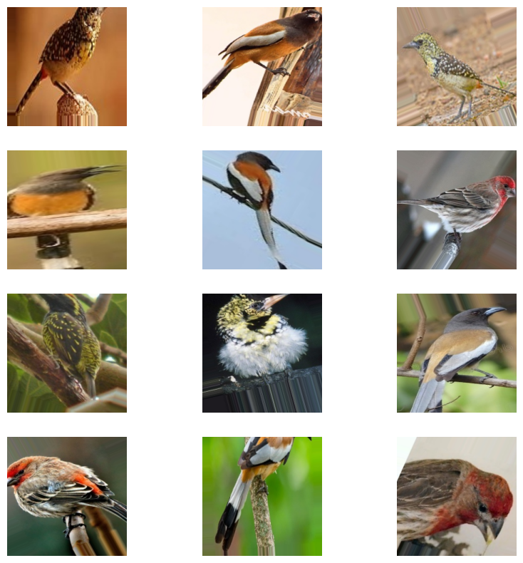

```python
#data augmentation model
plt.figure(figsize=(10,10))
for i in range(12):
    image, label = training_generator.next()
    plt.subplot(4, 3, i + 1)
    plt.imshow(image[0].astype("uint8"))
    plt.axis("off")
plt.show()
```

3. Fine-Tune VGG16 (pre-trained on imagenet), to classify the 3 classes (2 points)

```python
model = VGG16(weights='imagenet', include_top=False, input_shape=(224, 224, 3))
model.summary()
```

```
Model: "vgg16"
_________________________________________________________________
 Layer (type)                Output Shape              Param #
=================================================================
 input_1 (InputLayer)        [(None, 224, 224, 3)]     0

 block1_conv1 (Conv2D)       (None, 224, 224, 64)      1792

 block1_conv2 (Conv2D)       (None, 224, 224, 64)      36928

 block1_pool (MaxPooling2D)  (None, 112, 112, 64)      0

 block2_conv1 (Conv2D)       (None, 112, 112, 128)     73856

 block2_conv2 (Conv2D)       (None, 112, 112, 128)     147584

 block2_pool (MaxPooling2D)  (None, 56, 56, 128)       0

 block3_conv1 (Conv2D)       (None, 56, 56, 256)       295168

 block3_conv2 (Conv2D)       (None, 56, 56, 256)       590080

 block3_conv3 (Conv2D)       (None, 56, 56, 256)       590080

 block3_pool (MaxPooling2D)  (None, 28, 28, 256)       0

 block4_conv1 (Conv2D)       (None, 28, 28, 512)       1180160

 block4_conv2 (Conv2D)       (None, 28, 28, 512)       2359808

 block4_conv3 (Conv2D)       (None, 28, 28, 512)       2359808

 block4_pool (MaxPooling2D)  (None, 14, 14, 512)       0

 block5_conv1 (Conv2D)       (None, 14, 14, 512)       2359808

 block5_conv2 (Conv2D)       (None, 14, 14, 512)       2359808

 block5_conv3 (Conv2D)       (None, 14, 14, 512)       2359808

 block5_pool (MaxPooling2D)  (None, 7, 7, 512)         0

=================================================================
Total params: 14,714,688
Trainable params: 14,714,688
Non-trainable params: 0
_________________________________________________________________
```

```python
#freezing the layers of VGG16 model
for layer in model.layers:
    layer.trainable = False

x = model.output
x = GlobalAveragePooling2D()(x)
x = Dense(512, activation='relu')(x)
predictions = Dense(3, activation='softmax')(x)
model = Model(inputs=model.input, outputs=predictions)

model.compile(optimizer="Adam", loss='categorical_crossentropy', metrics=['accuracy'])
newmodel = model.fit(training_generator,epochs=10,validation_data=validating_generator)
```

[output not shown]

4. Explore the model performance: accuracy, confusion metric, precision, recall, F1-score, precision-recall curve and its area under the curve (AUC).

```python
pred= model.predict(validating_generator)
pred_cls = np.argmax(pred, axis=1) #predicted classes
real_classes = validating_generator.classes #actual classes
class_labels = list(validating_generator.class_indices.keys())

cf_matrix = confusion_matrix(real_classes, pred_cls)

print("Classfication report:\n", classification_report(real_classes, pred_cls, target_names=validating_generator.class_indices.keys()))
print("The classification matrix:\n", cf_matrix)
```

```
Classfication report:
                   precision    recall  f1-score   support

D-ARNAUDS BARBET       0.40      0.40      0.40         5
     HOUSE FINCH       0.40      0.40      0.40         5
    RUFOUS TREPE       0.20      0.20      0.20         5

        accuracy                           0.33        15
       macro avg       0.33      0.33      0.33        15
    weighted avg       0.33      0.33      0.33        15

The classification matrix:
 [[2 1 2]
 [1 2 2]
 [2 2 1]]
```

AUC and precision recall curve.

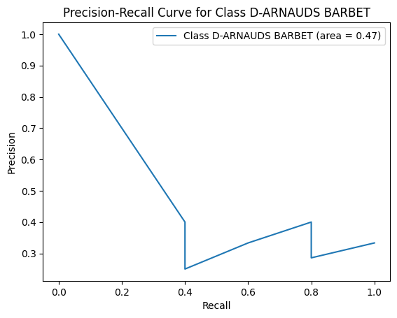

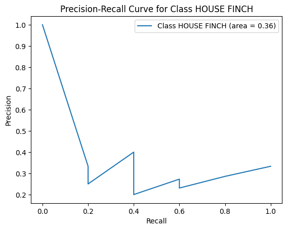

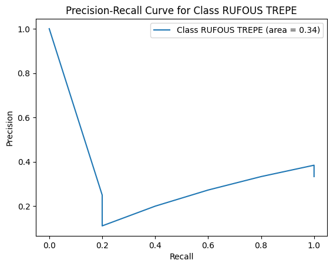

```python
labels = keras.utils.to_categorical(real_classes, num_classes=3)  # Convert labels to binary format

for i in range(3):
    precision, recall, _ = precision_recall_curve(labels[:, i], pred[:, i])
    auc_score = auc(recall, precision)
    plt.figure()
    plt.plot(recall, precision, label=f'Class {class_labels[i]} (area = {auc_score:.2f})')
    plt.xlabel('Recall')
    plt.ylabel('Precision')
    plt.title(f'Precision-Recall Curve for Class {class_labels[i]}')
    plt.legend(loc="best")
    plt.show()
```

Explore specific examples where the model failed

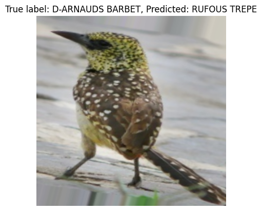

[figure not shown]

[figure not shown]

[figure not shown]

[figure not shown]

```python
wrong_indices = np.where(pred_cls != real_classes)[0]
sample_images, _ = next(validating_generator)  #getting next set of images

#Displaying where the model was wrong
for i in wrong_indices[:5]: #getting 5 images
    plt.imshow(sample_images[i].astype('uint8'))
    plt.title(f"True label: {class_labels[real_classes[i]]}, Predicted: {class_labels[pred_cls[i]]}")
    plt.axis("off")
    plt.show()
```